# RSA_Graphs

Estibaliz Herrera

2026-02-03

[output not shown]

preview of color palettes

PLOTS COLOR CODE

****GRAPHS**** ************************** HIPPOCAMPUS OL ************************** # ———> I have checked bonferroni and anovas values match JASP -> Repeated measures ANOVA Learning stage (Early,Late) x Hall (Cue period, 1st hall, 2nd hall, goal) (1) OL HC

```
## # A tibble: 160 × 7
## # Groups:   ID, learningStage, Hall [160]
##    ID    raw_name                    RSA ROI   learningStage Hall  Overlappicity
##    <chr> <chr>                     <dbl> <chr> <chr>         <fct> <chr>
##  1 s01   'ol_new_early_w_ol_new… 0.0281  Hipp… Early         Goal  OL
##  2 s01   'ol_new_late_w_ol_new_… 0.0263  Hipp… Late          Goal  OL
##  3 s01   'ol_new_early_w_ol_new… 0.0173  Hipp… Early         2nd … OL
##  4 s01   'ol_new_late_w_ol_new_… 0.0246  Hipp… Late          2nd … OL
##  5 s01   'ol_new_early_w_ol_new… 0.00717 Hipp… Early         1st … OL
##  6 s01   'ol_new_late_w_ol_new_… 0.00419 Hipp… Late          1st … OL
##  7 s01   'ol_new_early_w_ol_new… 0.0240  Hipp… Early         Cue … OL
##  8 s01   'ol_new_late_w_ol_new_… 0.0462  Hipp… Late          Cue … OL
##  9 s02   'ol_new_early_w_ol_new… 0.00577 Hipp… Early         Goal  OL
## 10 s02   'ol_new_late_w_ol_new_… 0.00736 Hipp… Late          Goal  OL
## # ℹ 150 more rows
```

ANOVA

```
## Anova Table (Type 3 tests)
##
## Response: RSA
##                    num Df den Df        MSE      F      pes    Pr(>F)
## learningStage      1.0000 19.000 0.00073565 1.3655 0.067049 0.2570438
## Hall               2.2688 43.107 0.00025765 8.5177 0.309536 0.0004766 ***
## learningStage:Hall 2.2488 42.727 0.00034353 1.0467 0.052211 0.3667083
## ---
## Signif. codes:  0 '***' 0.001 '**' 0.01 '*' 0.05 '.' 0.1 ' ' 1
```

```
##               Effect                df1      df2     F       p   η.p
## 1      learningStage      learningStage 1.000000 1.365 = 0.257 0.067
## 2               Hall               Hall 2.268805 8.518  < .001 0.310
## 3 learningStage:Hall learningStage:Hall 2.248770 1.047 = 0.367 0.052
```

POST-HOCs

|  | contrast | estimate | SE | df | t.ratio | p.value | cohen_d | t | pHolms |
| --- | --- | --- | --- | --- | --- | --- | --- | --- | --- |
| 1 | Early Cue.period - Late Cue.period | 0.005 | 0.007 | 19 | 0.6825651 | 1.00000000 | 0.505 | 0.68 | = 1 |
| 2 | Early Cue.period - Early X1st.hallway | 0.003 | 0.005 | 19 | 0.6481432 | 1.00000000 | 0.424 | 0.65 | = 1 |
| 3 | Early Cue.period - Late X1st.hallway | 0.005 | 0.006 | 19 | 0.8549020 | 1.00000000 | 0.589 | 0.85 | = 1 |
| 4 | Early Cue.period - Early X2nd.hallway | -0.001 | 0.005 | 19 | -0.2120702 | 1.00000000 | -0.141 | -0.21 | = 1 |
| 5 | Early Cue.period - Late X2nd.hallway | 0.000 | 0.005 | 19 | -0.0380900 | 1.00000000 | 0.000 | -0.04 | = 1 |
| 6 | Early Cue.period - Early Goal | -0.016 | 0.005 | 19 | -3.0282476 | 0.17978908 | -2.263 | -3.03 | = 0.18 |
| 7 | Early Cue.period - Late Goal | -0.004 | 0.007 | 19 | -0.5614856 | 1.00000000 | -0.404 | -0.56 | = 1 |
| 8 | Late Cue.period - Early X1st.hallway | -0.001 | 0.005 | 19 | -0.2688704 | 1.00000000 | -0.141 | -0.27 | = 1 |
| 9 | Late Cue.period - Late X1st.hallway | 0.001 | 0.004 | 19 | 0.1408253 | 1.00000000 | 0.177 | 0.14 | = 1 |
| 10 | Late Cue.period - Early X2nd.hallway | -0.006 | 0.005 | 19 | -1.1269165 | 1.00000000 | -0.849 | -1.13 | = 1 |

[output cut: 18 more lines]

|  | contrast | estimate | SE | df | t.ratio | p.value | cohen_d | t | pBonf |
| --- | --- | --- | --- | --- | --- | --- | --- | --- | --- |
| 1 | Early Cue.period - Late Cue.period | 0.005 | 0.007 | 19 | 0.6825651 | 1.00000000 | 0.505 | 0.68 | = 1 |
| 2 | Early Cue.period - Early X1st.hallway | 0.003 | 0.005 | 19 | 0.6481432 | 1.00000000 | 0.424 | 0.65 | = 1 |
| 3 | Early Cue.period - Late X1st.hallway | 0.005 | 0.006 | 19 | 0.8549020 | 1.00000000 | 0.589 | 0.85 | = 1 |
| 4 | Early Cue.period - Early X2nd.hallway | -0.001 | 0.005 | 19 | -0.2120702 | 1.00000000 | -0.141 | -0.21 | = 1 |
| 5 | Early Cue.period - Late X2nd.hallway | 0.000 | 0.005 | 19 | -0.0380900 | 1.00000000 | 0.000 | -0.04 | = 1 |
| 6 | Early Cue.period - Early Goal | -0.016 | 0.005 | 19 | -3.0282476 | 0.19361901 | -2.263 | -3.03 | = 0.194 |
| 7 | Early Cue.period - Late Goal | -0.004 | 0.007 | 19 | -0.5614856 | 1.00000000 | -0.404 | -0.56 | = 1 |
| 8 | Late Cue.period - Early X1st.hallway | -0.001 | 0.005 | 19 | -0.2688704 | 1.00000000 | -0.141 | -0.27 | = 1 |
| 9 | Late Cue.period - Late X1st.hallway | 0.001 | 0.004 | 19 | 0.1408253 | 1.00000000 | 0.177 | 0.14 | = 1 |
| 10 | Late Cue.period - Early X2nd.hallway | -0.006 | 0.005 | 19 | -1.1269165 | 1.00000000 | -0.849 | -1.13 | = 1 |

[output cut: 18 more lines]

DESCRIPTIVES

```
## # A tibble: 8 × 6
##   learningStage Hall            N  Mean    SD    SE
##   <chr>         <fct>       <int> <dbl> <dbl> <dbl>
## 1 Early         Cue period     20 0.017 0.023 0.005
## 2 Early         1st hallway    20 0.014 0.013 0.003
## 3 Early         2nd hallway    20 0.018 0.014 0.003
## 4 Early         Goal           20 0.033 0.027 0.006
## 5 Late          Cue period     20 0.012 0.021 0.005
## 6 Late          1st hallway    20 0.012 0.013 0.003
## 7 Late          2nd hallway    20 0.017 0.015 0.003
## 8 Late          Goal           20 0.021 0.026 0.006
```

PLOTTING OL HIPPOCAMPUS (LearningStage x Hall)

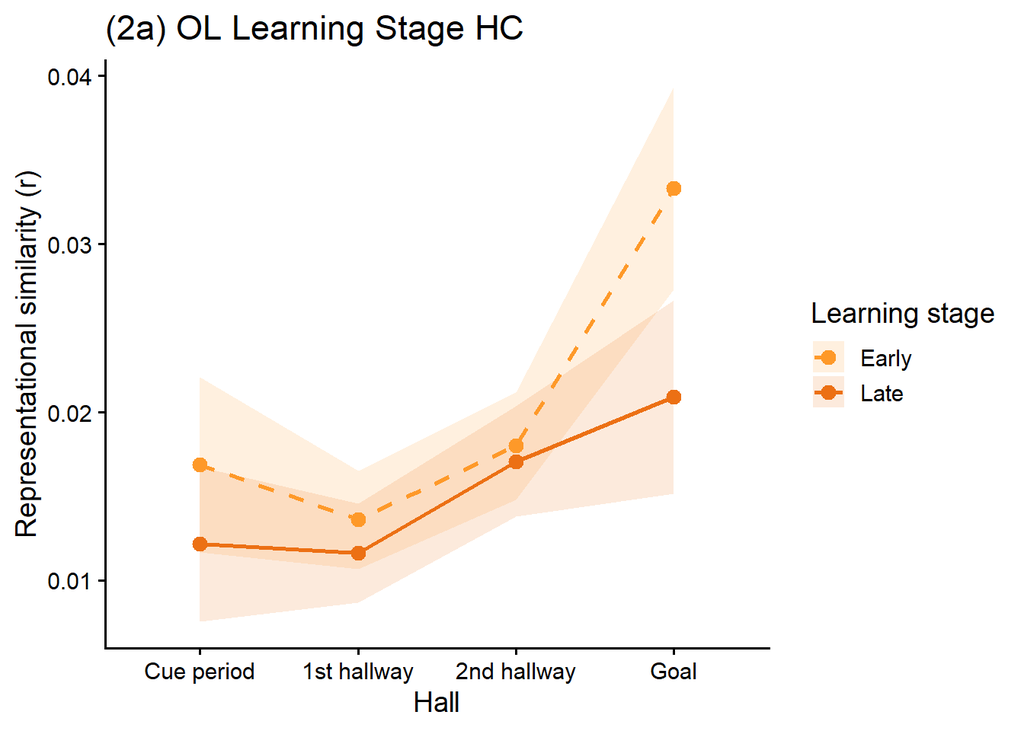

HIPPOCAMPUS NOL **************************

-> Repeated measures ANOVA Learning stage (Early,Late) x Hall (Cue period, 1st hall, 2nd hall, goal) (1) NOL HC

```
## # A tibble: 160 × 7
## # Groups:   ID, learningStage, Hall [160]
##    ID    raw_name                    RSA ROI   learningStage Hall  Overlappicity
##    <chr> <chr>                     <dbl> <chr> <chr>         <fct> <chr>
##  1 s01   'nol_new_early_w_nol_…  0.0253  Hipp… Early         Goal  NOL
##  2 s01   'nol_new_late_w_nol_n…  0.00652 Hipp… Late          Goal  NOL
##  3 s01   'nol_new_early_w_nol_…  0.0155  Hipp… Early         2nd … NOL
##  4 s01   'nol_new_late_w_nol_n…  0.0219  Hipp… Late          2nd … NOL
##  5 s01   'nol_new_early_w_nol_…  0.00548 Hipp… Early         1st … NOL
##  6 s01   'nol_new_late_w_nol_n…  0.0188  Hipp… Late          1st … NOL
##  7 s01   'nol_new_early_w_nol_…  0.0351  Hipp… Early         Cue … NOL
##  8 s01   'nol_new_late_w_nol_n…  0.0137  Hipp… Late          Cue … NOL
##  9 s02   'nol_new_early_w_nol_… -0.00589 Hipp… Early         Goal  NOL
## 10 s02   'nol_new_late_w_nol_n… -0.0125  Hipp… Late          Goal  NOL
## # ℹ 150 more rows
```

ANOVA

```
## Anova Table (Type 3 tests)
##
## Response: RSA
##                    num Df den Df        MSE      F      pes  Pr(>F)
## learningStage      1.0000 19.000 0.00063148 1.2710 0.062701 0.27361
## Hall               2.0030 38.057 0.00032189 2.7252 0.125438 0.07825 .
## learningStage:Hall 2.2416 42.591 0.00029146 1.6913 0.081741 0.19345
## ---
## Signif. codes:  0 '***' 0.001 '**' 0.01 '*' 0.05 '.' 0.1 ' ' 1
```

```
##               Effect                df1      df2     F       p   η.p
## 1      learningStage      learningStage 1.000000 1.271 = 0.274 0.063
## 2               Hall               Hall 2.003000 2.725 = 0.078 0.125
## 3 learningStage:Hall learningStage:Hall 2.241636 1.691 = 0.193 0.082
```

POST-HOCs

|  | contrast | estimate | SE | df | t.ratio | p.value | cohen_d | t | pHolms |
| --- | --- | --- | --- | --- | --- | --- | --- | --- | --- |
| 1 | Early Cue.period - Late Cue.period | 0.008 | 0.006 | 19 | 1.38263995 | 1.000000000 | 0.943 | 1.38 | = 1 |
| 2 | Early Cue.period - Early X1st.hallway | 0.013 | 0.005 | 19 | 2.85923263 | 0.271008267 | 1.838 | 2.86 | = 0.271 |
| 3 | Early Cue.period - Late X1st.hallway | 0.009 | 0.005 | 19 | 1.78604956 | 1.000000000 | 1.273 | 1.79 | = 1 |
| 4 | Early Cue.period - Early X2nd.hallway | 0.000 | 0.005 | 19 | 0.07004897 | 1.000000000 | 0.000 | 0.07 | = 1 |
| 5 | Early Cue.period - Late X2nd.hallway | 0.006 | 0.004 | 19 | 1.41183491 | 1.000000000 | 1.061 | 1.41 | = 1 |
| 6 | Early Cue.period - Early Goal | -0.002 | 0.004 | 19 | -0.40472530 | 1.000000000 | -0.354 | -0.40 | = 1 |
| 7 | Early Cue.period - Late Goal | 0.006 | 0.007 | 19 | 0.92691708 | 1.000000000 | 0.606 | 0.93 | = 1 |
| 8 | Late Cue.period - Early X1st.hallway | 0.005 | 0.006 | 19 | 0.80277737 | 1.000000000 | 0.589 | 0.80 | = 1 |
| 9 | Late Cue.period - Late X1st.hallway | 0.000 | 0.006 | 19 | 0.01556895 | 1.000000000 | 0.000 | 0.02 | = 1 |
| 10 | Late Cue.period - Early X2nd.hallway | -0.008 | 0.007 | 19 | -1.14561808 | 1.000000000 | -0.808 | -1.15 | = 1 |

[output cut: 18 more lines]

|  | contrast | estimate | SE | df | t.ratio | p.value | cohen_d | t | pBonf |
| --- | --- | --- | --- | --- | --- | --- | --- | --- | --- |
| 1 | Early Cue.period - Late Cue.period | 0.008 | 0.006 | 19 | 1.38263995 | 1.000000000 | 0.943 | 1.38 | = 1 |
| 2 | Early Cue.period - Early X1st.hallway | 0.013 | 0.005 | 19 | 2.85923263 | 0.281045610 | 1.838 | 2.86 | = 0.281 |
| 3 | Early Cue.period - Late X1st.hallway | 0.009 | 0.005 | 19 | 1.78604956 | 1.000000000 | 1.273 | 1.79 | = 1 |
| 4 | Early Cue.period - Early X2nd.hallway | 0.000 | 0.005 | 19 | 0.07004897 | 1.000000000 | 0.000 | 0.07 | = 1 |
| 5 | Early Cue.period - Late X2nd.hallway | 0.006 | 0.004 | 19 | 1.41183491 | 1.000000000 | 1.061 | 1.41 | = 1 |
| 6 | Early Cue.period - Early Goal | -0.002 | 0.004 | 19 | -0.40472530 | 1.000000000 | -0.354 | -0.40 | = 1 |
| 7 | Early Cue.period - Late Goal | 0.006 | 0.007 | 19 | 0.92691708 | 1.000000000 | 0.606 | 0.93 | = 1 |
| 8 | Late Cue.period - Early X1st.hallway | 0.005 | 0.006 | 19 | 0.80277737 | 1.000000000 | 0.589 | 0.80 | = 1 |
| 9 | Late Cue.period - Late X1st.hallway | 0.000 | 0.006 | 19 | 0.01556895 | 1.000000000 | 0.000 | 0.02 | = 1 |
| 10 | Late Cue.period - Early X2nd.hallway | -0.008 | 0.007 | 19 | -1.14561808 | 1.000000000 | -0.808 | -1.15 | = 1 |

[output cut: 18 more lines]

DESCRIPTIVES

```
## # A tibble: 8 × 6
##   learningStage Hall            N  Mean    SD    SE
##   <chr>         <fct>       <int> <dbl> <dbl> <dbl>
## 1 Early         Cue period     20 0.022 0.02  0.004
## 2 Early         1st hallway    20 0.009 0.009 0.002
## 3 Early         2nd hallway    20 0.021 0.017 0.004
## 4 Early         Goal           20 0.023 0.027 0.006
## 5 Late          Cue period     20 0.013 0.023 0.005
## 6 Late          1st hallway    20 0.013 0.015 0.003
## 7 Late          2nd hallway    20 0.015 0.014 0.003
## 8 Late          Goal           20 0.015 0.022 0.005
```

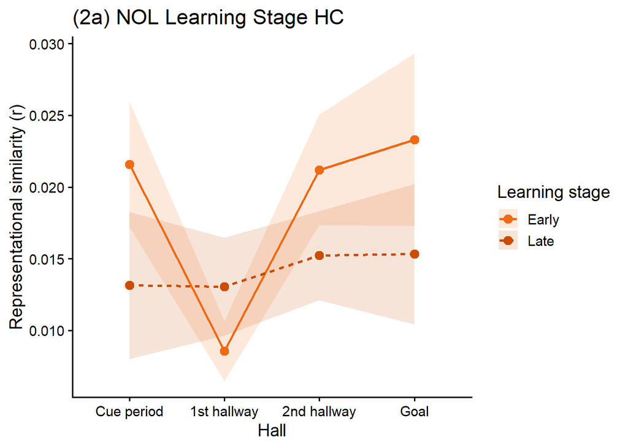

RSC OL **************************

-> Repeated meausures ANOVA Learning stage (Early,Late) x Hall (Cue period, 1st hall, 2nd hall, goal) (1) OL RSC

```
## # A tibble: 160 × 7
## # Groups:   ID, learningStage, Hall [160]
##    ID    raw_name                    RSA ROI   learningStage Hall  Overlappicity
##    <chr> <chr>                     <dbl> <chr> <chr>         <fct> <chr>
##  1 s01   'ol_new_early_w_ol_new_… 0.0933 RSC   Early         Goal  OL
##  2 s01   'ol_new_late_w_ol_new_l… 0.0572 RSC   Late          Goal  OL
##  3 s01   'ol_new_early_w_ol_new_… 0.0458 RSC   Early         2nd … OL
##  4 s01   'ol_new_late_w_ol_new_l… 0.0487 RSC   Late          2nd … OL
##  5 s01   'ol_new_early_w_ol_new_… 0.0411 RSC   Early         1st … OL
##  6 s01   'ol_new_late_w_ol_new_l… 0.0351 RSC   Late          1st … OL
##  7 s01   'ol_new_early_w_ol_new_… 0.0639 RSC   Early         Cue … OL
##  8 s01   'ol_new_late_w_ol_new_l… 0.0648 RSC   Late          Cue … OL
##  9 s02   'ol_new_early_w_ol_new_… 0.0440 RSC   Early         Goal  OL
## 10 s02   'ol_new_late_w_ol_new_l… 0.154  RSC   Late          Goal  OL
## # ℹ 150 more rows
```

ANOVA

```
## Anova Table (Type 3 tests)
##
## Response: RSA
##                    num Df den Df        MSE       F     pes    Pr(>F)
## learningStage      1.0000 19.000 0.00196387  0.7671 0.03881    0.3921
## Hall               2.4873 47.259 0.00092951 11.0212 0.36711 3.853e-05 ***
## learningStage:Hall 1.6798 31.916 0.00242686  0.1963 0.01023    0.7849
## ---
## Signif. codes:  0 '***' 0.001 '**' 0.01 '*' 0.05 '.' 0.1 ' ' 1
```

```
##               Effect                df1      df2      F       p   η.p
## 1      learningStage      learningStage 1.000000  0.767 = 0.392 0.039
## 2               Hall               Hall 2.487325 11.021  < .001 0.367
## 3 learningStage:Hall learningStage:Hall 1.679780  0.196 = 0.785 0.010
```

POST-HOCs

|  | contrast | estimate | SE | df | t.ratio | p.value | cohen_d | t | pHolms |
| --- | --- | --- | --- | --- | --- | --- | --- | --- | --- |
| 1 | Early Cue.period - Late Cue.period | 0.011 | 0.011 | 19 | 0.93868120 | 1.00000000 | 0.707 | 0.94 | = 1 |
| 2 | Early Cue.period - Early X1st.hallway | 0.010 | 0.008 | 19 | 1.20854563 | 1.00000000 | 0.884 | 1.21 | = 1 |
| 3 | Early Cue.period - Late X1st.hallway | 0.009 | 0.010 | 19 | 0.82715897 | 1.00000000 | 0.636 | 0.83 | = 1 |
| 4 | Early Cue.period - Early X2nd.hallway | -0.010 | 0.009 | 19 | -1.04933141 | 1.00000000 | -0.786 | -1.05 | = 1 |
| 5 | Early Cue.period - Late X2nd.hallway | -0.001 | 0.011 | 19 | -0.07243439 | 1.00000000 | -0.064 | -0.07 | = 1 |
| 6 | Early Cue.period - Early Goal | -0.027 | 0.008 | 19 | -3.21424167 | 0.11598109 | -2.386 | -3.21 | = 0.116 |
| 7 | Early Cue.period - Late Goal | -0.020 | 0.014 | 19 | -1.42201307 | 1.00000000 | -1.010 | -1.42 | = 1 |
| 8 | Late Cue.period - Early X1st.hallway | -0.001 | 0.009 | 19 | -0.10230761 | 1.00000000 | -0.079 | -0.10 | = 1 |
| 9 | Late Cue.period - Late X1st.hallway | -0.002 | 0.010 | 19 | -0.20973071 | 1.00000000 | -0.141 | -0.21 | = 1 |
| 10 | Late Cue.period - Early X2nd.hallway | -0.020 | 0.011 | 19 | -1.83675944 | 1.00000000 | -1.286 | -1.84 | = 1 |

[output cut: 18 more lines]

|  | contrast | estimate | SE | df | t.ratio | p.value | cohen_d | t | pBonf |
| --- | --- | --- | --- | --- | --- | --- | --- | --- | --- |
| 1 | Early Cue.period - Late Cue.period | 0.011 | 0.011 | 19 | 0.93868120 | 1.00000000 | 0.707 | 0.94 | = 1 |
| 2 | Early Cue.period - Early X1st.hallway | 0.010 | 0.008 | 19 | 1.20854563 | 1.00000000 | 0.884 | 1.21 | = 1 |
| 3 | Early Cue.period - Late X1st.hallway | 0.009 | 0.010 | 19 | 0.82715897 | 1.00000000 | 0.636 | 0.83 | = 1 |
| 4 | Early Cue.period - Early X2nd.hallway | -0.010 | 0.009 | 19 | -1.04933141 | 1.00000000 | -0.786 | -1.05 | = 1 |
| 5 | Early Cue.period - Late X2nd.hallway | -0.001 | 0.011 | 19 | -0.07243439 | 1.00000000 | -0.064 | -0.07 | = 1 |
| 6 | Early Cue.period - Early Goal | -0.027 | 0.008 | 19 | -3.21424167 | 0.12784818 | -2.386 | -3.21 | = 0.128 |
| 7 | Early Cue.period - Late Goal | -0.020 | 0.014 | 19 | -1.42201307 | 1.00000000 | -1.010 | -1.42 | = 1 |
| 8 | Late Cue.period - Early X1st.hallway | -0.001 | 0.009 | 19 | -0.10230761 | 1.00000000 | -0.079 | -0.10 | = 1 |
| 9 | Late Cue.period - Late X1st.hallway | -0.002 | 0.010 | 19 | -0.20973071 | 1.00000000 | -0.141 | -0.21 | = 1 |
| 10 | Late Cue.period - Early X2nd.hallway | -0.020 | 0.011 | 19 | -1.83675944 | 1.00000000 | -1.286 | -1.84 | = 1 |

[output cut: 18 more lines]

DESCRIPTIVES

```
## # A tibble: 8 × 6
##   learningStage Hall            N  Mean    SD    SE
##   <chr>         <fct>       <int> <dbl> <dbl> <dbl>
## 1 Early         Cue period     20 0.058 0.035 0.008
## 2 Early         1st hallway    20 0.048 0.028 0.006
## 3 Early         2nd hallway    20 0.067 0.042 0.009
## 4 Early         Goal           20 0.084 0.044 0.01
## 5 Late          Cue period     20 0.047 0.039 0.009
## 6 Late          1st hallway    20 0.049 0.031 0.007
## 7 Late          2nd hallway    20 0.058 0.048 0.011
## 8 Late          Goal           20 0.078 0.053 0.012
```

PLOTTING OL RSC (LearningStage x Hall)

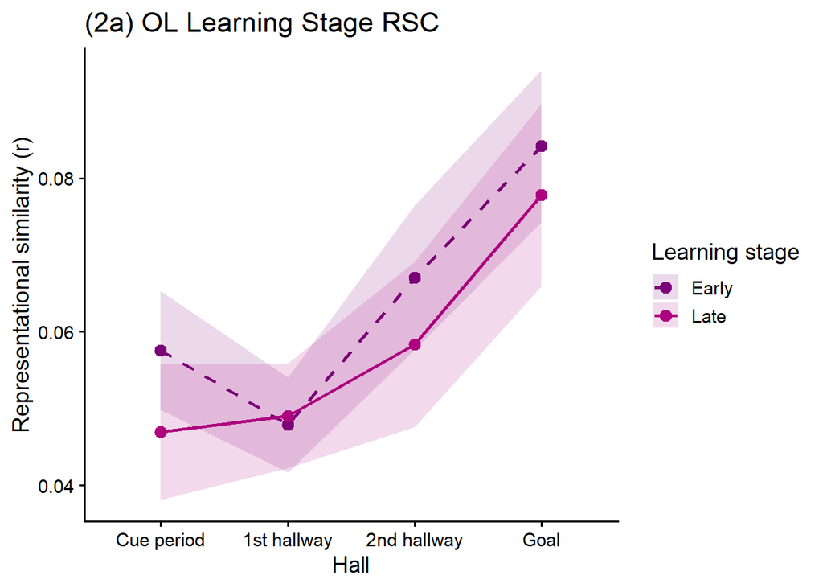

RSC NOL **************************

-> Repeated meausures ANOVA Learning stage (Early,Late) x Hall (Cue period, 1st hall, 2nd hall, goal) (1) NOL RSC

```
## # A tibble: 160 × 7
## # Groups:   ID, learningStage, Hall [160]
##    ID    raw_name                    RSA ROI   learningStage Hall  Overlappicity
##    <chr> <chr>                     <dbl> <chr> <chr>         <fct> <chr>
##  1 s01   'nol_new_early_w_nol_ne… 0.0785 RSC   Early         Goal  NOL
##  2 s01   'nol_new_late_w_nol_new… 0.0464 RSC   Late          Goal  NOL
##  3 s01   'nol_new_early_w_nol_ne… 0.0595 RSC   Early         2nd … NOL
##  4 s01   'nol_new_late_w_nol_new… 0.0974 RSC   Late          2nd … NOL
##  5 s01   'nol_new_early_w_nol_ne… 0.0576 RSC   Early         1st … NOL
##  6 s01   'nol_new_late_w_nol_new… 0.0813 RSC   Late          1st … NOL
##  7 s01   'nol_new_early_w_nol_ne… 0.0882 RSC   Early         Cue … NOL
##  8 s01   'nol_new_late_w_nol_new… 0.0691 RSC   Late          Cue … NOL
##  9 s02   'nol_new_early_w_nol_ne… 0.0146 RSC   Early         Goal  NOL
## 10 s02   'nol_new_late_w_nol_new… 0.0702 RSC   Late          Goal  NOL
## # ℹ 150 more rows
```

ANOVA

```
## Anova Table (Type 3 tests)
##
## Response: RSA
##                    num Df den Df        MSE      F      pes  Pr(>F)
## learningStage      1.0000 19.000 0.00216413 0.2499 0.012982 0.62289
## Hall               2.6357 50.079 0.00071272 3.1701 0.142989 0.03777 *
## learningStage:Hall 2.1514 40.876 0.00149018 0.3695 0.019076 0.70852
## ---
## Signif. codes:  0 '***' 0.001 '**' 0.01 '*' 0.05 '.' 0.1 ' ' 1
```

```
##               Effect                df1      df2     F       p   η.p
## 1      learningStage      learningStage 1.000000 0.250 = 0.623 0.013
## 2               Hall               Hall 2.635728 3.170 = 0.038 0.143
## 3 learningStage:Hall learningStage:Hall 2.151388 0.369 = 0.709 0.019
```

POST-HOCs

|  | contrast | estimate | SE | df | t.ratio | p.value | cohen_d | t | pHolms |
| --- | --- | --- | --- | --- | --- | --- | --- | --- | --- |
| 1 | Early Cue.period - Late Cue.period | -0.004 | 0.011 | 19 | -0.35424314 | 1.00000000 | -0.257 | -0.35 | = 1 |
| 2 | Early Cue.period - Early X1st.hallway | 0.009 | 0.007 | 19 | 1.36837541 | 1.00000000 | 0.909 | 1.37 | = 1 |
| 3 | Early Cue.period - Late X1st.hallway | -0.001 | 0.010 | 19 | -0.07665481 | 1.00000000 | -0.071 | -0.08 | = 1 |
| 4 | Early Cue.period - Early X2nd.hallway | -0.012 | 0.008 | 19 | -1.52754615 | 1.00000000 | -1.061 | -1.53 | = 1 |
| 5 | Early Cue.period - Late X2nd.hallway | -0.007 | 0.008 | 19 | -0.86316892 | 1.00000000 | -0.619 | -0.86 | = 1 |
| 6 | Early Cue.period - Early Goal | -0.008 | 0.009 | 19 | -0.87700156 | 1.00000000 | -0.629 | -0.88 | = 1 |
| 7 | Early Cue.period - Late Goal | -0.014 | 0.012 | 19 | -1.09232554 | 1.00000000 | -0.825 | -1.09 | = 1 |
| 8 | Late Cue.period - Early X1st.hallway | 0.013 | 0.009 | 19 | 1.51363730 | 1.00000000 | 1.021 | 1.51 | = 1 |
| 9 | Late Cue.period - Late X1st.hallway | 0.003 | 0.010 | 19 | 0.29647787 | 1.00000000 | 0.212 | 0.30 | = 1 |
| 10 | Late Cue.period - Early X2nd.hallway | -0.008 | 0.010 | 19 | -0.80562250 | 1.00000000 | -0.566 | -0.81 | = 1 |

[output cut: 18 more lines]

|  | contrast | estimate | SE | df | t.ratio | p.value | cohen_d | t | pBonf |
| --- | --- | --- | --- | --- | --- | --- | --- | --- | --- |
| 1 | Early Cue.period - Late Cue.period | -0.004 | 0.011 | 19 | -0.35424314 | 1.00000000 | -0.257 | -0.35 | = 1 |
| 2 | Early Cue.period - Early X1st.hallway | 0.009 | 0.007 | 19 | 1.36837541 | 1.00000000 | 0.909 | 1.37 | = 1 |
| 3 | Early Cue.period - Late X1st.hallway | -0.001 | 0.010 | 19 | -0.07665481 | 1.00000000 | -0.071 | -0.08 | = 1 |
| 4 | Early Cue.period - Early X2nd.hallway | -0.012 | 0.008 | 19 | -1.52754615 | 1.00000000 | -1.061 | -1.53 | = 1 |
| 5 | Early Cue.period - Late X2nd.hallway | -0.007 | 0.008 | 19 | -0.86316892 | 1.00000000 | -0.619 | -0.86 | = 1 |
| 6 | Early Cue.period - Early Goal | -0.008 | 0.009 | 19 | -0.87700156 | 1.00000000 | -0.629 | -0.88 | = 1 |
| 7 | Early Cue.period - Late Goal | -0.014 | 0.012 | 19 | -1.09232554 | 1.00000000 | -0.825 | -1.09 | = 1 |
| 8 | Late Cue.period - Early X1st.hallway | 0.013 | 0.009 | 19 | 1.51363730 | 1.00000000 | 1.021 | 1.51 | = 1 |
| 9 | Late Cue.period - Late X1st.hallway | 0.003 | 0.010 | 19 | 0.29647787 | 1.00000000 | 0.212 | 0.30 | = 1 |
| 10 | Late Cue.period - Early X2nd.hallway | -0.008 | 0.010 | 19 | -0.80562250 | 1.00000000 | -0.566 | -0.81 | = 1 |

[output cut: 18 more lines]

DESCRIPTIVES

```
## # A tibble: 8 × 6
##   learningStage Hall            N  Mean    SD    SE
##   <chr>         <fct>       <int> <dbl> <dbl> <dbl>
## 1 Early         Cue period     20 0.051 0.039 0.009
## 2 Early         1st hallway    20 0.041 0.026 0.006
## 3 Early         2nd hallway    20 0.063 0.04  0.009
## 4 Early         Goal           20 0.058 0.047 0.011
## 5 Late          Cue period     20 0.054 0.042 0.009
## 6 Late          1st hallway    20 0.051 0.027 0.006
## 7 Late          2nd hallway    20 0.058 0.033 0.007
## 8 Late          Goal           20 0.064 0.047 0.01
```

PLOTTING NOL RSC (LearningStage x Hall)

[figure not shown]

RSComplex OL **************************

-> Repeated meausures ANOVA Learning stage (Early,Late) x Hall (Cue period, 1st hall, 2nd hall, goal) (1) OL RSComplex

```
## # A tibble: 160 × 7
## # Groups:   ID, learningStage, Hall [160]
##    ID    raw_name                    RSA ROI   learningStage Hall  Overlappicity
##    <chr> <chr>                     <dbl> <chr> <chr>         <fct> <chr>
##  1 s01   'ol_new_early_w_ol_new_… 0.0601 Comp… Early         Goal  OL
##  2 s01   'ol_new_late_w_ol_new_l… 0.0541 Comp… Late          Goal  OL
##  3 s01   'ol_new_early_w_ol_new_… 0.0361 Comp… Early         2nd … OL
##  4 s01   'ol_new_late_w_ol_new_l… 0.0447 Comp… Late          2nd … OL
##  5 s01   'ol_new_early_w_ol_new_… 0.0534 Comp… Early         1st … OL
##  6 s01   'ol_new_late_w_ol_new_l… 0.0587 Comp… Late          1st … OL
##  7 s01   'ol_new_early_w_ol_new_… 0.0465 Comp… Early         Cue … OL
##  8 s01   'ol_new_late_w_ol_new_l… 0.0693 Comp… Late          Cue … OL
##  9 s02   'ol_new_early_w_ol_new_… 0.0285 Comp… Early         Goal  OL
## 10 s02   'ol_new_late_w_ol_new_l… 0.138  Comp… Late          Goal  OL
## # ℹ 150 more rows
```

ANOVA

```
## Anova Table (Type 3 tests)
##
## Response: RSA
##                    num Df den Df       MSE      F      pes  Pr(>F)
## learningStage      1.0000 19.000 0.0016312 1.5372 0.074849 0.23013
## Hall               1.9752 37.528 0.0024868 4.2860 0.184059 0.02145 *
## learningStage:Hall 1.6864 32.042 0.0034361 0.3656 0.018877 0.66087
## ---
## Signif. codes:  0 '***' 0.001 '**' 0.01 '*' 0.05 '.' 0.1 ' ' 1
```

```
##               Effect                df1      df2     F       p   η.p
## 1      learningStage      learningStage 1.000000 1.537 = 0.230 0.075
## 2               Hall               Hall 1.975160 4.286 = 0.021 0.184
## 3 learningStage:Hall learningStage:Hall 1.686408 0.366 = 0.661 0.019
```

POST-HOCs

|  | contrast | estimate | SE | df | t.ratio | p.value | cohen_d | t | pHolms |
| --- | --- | --- | --- | --- | --- | --- | --- | --- | --- |
| 1 | Early Cue.period - Late Cue.period | 0.014 | 0.013 | 19 | 1.06899854 | 1.00000000 | 0.761 | 1.07 | = 1 |
| 2 | Early Cue.period - Early X1st.hallway | -0.008 | 0.013 | 19 | -0.59171591 | 1.00000000 | -0.435 | -0.59 | = 1 |
| 3 | Early Cue.period - Late X1st.hallway | -0.007 | 0.014 | 19 | -0.48852909 | 1.00000000 | -0.354 | -0.49 | = 1 |
| 4 | Early Cue.period - Early X2nd.hallway | -0.029 | 0.012 | 19 | -2.38219227 | 0.66756440 | -1.709 | -2.38 | = 0.668 |
| 5 | Early Cue.period - Late X2nd.hallway | -0.013 | 0.013 | 19 | -0.98827921 | 1.00000000 | -0.707 | -0.99 | = 1 |
| 6 | Early Cue.period - Early Goal | -0.021 | 0.012 | 19 | -1.75833628 | 1.00000000 | -1.237 | -1.76 | = 1 |
| 7 | Early Cue.period - Late Goal | -0.021 | 0.016 | 19 | -1.29287458 | 1.00000000 | -0.928 | -1.29 | = 1 |
| 8 | Late Cue.period - Early X1st.hallway | -0.022 | 0.013 | 19 | -1.63715780 | 1.00000000 | -1.197 | -1.64 | = 1 |
| 9 | Late Cue.period - Late X1st.hallway | -0.021 | 0.015 | 19 | -1.39133010 | 1.00000000 | -0.990 | -1.39 | = 1 |
| 10 | Late Cue.period - Early X2nd.hallway | -0.043 | 0.012 | 19 | -3.56894517 | 0.05529911 | -2.534 | -3.57 | = 0.055 |

[output cut: 18 more lines]

|  | contrast | estimate | SE | df | t.ratio | p.value | cohen_d | t | pBonf |
| --- | --- | --- | --- | --- | --- | --- | --- | --- | --- |
| 1 | Early Cue.period - Late Cue.period | 0.014 | 0.013 | 19 | 1.06899854 | 1.00000000 | 0.761 | 1.07 | = 1 |
| 2 | Early Cue.period - Early X1st.hallway | -0.008 | 0.013 | 19 | -0.59171591 | 1.00000000 | -0.435 | -0.59 | = 1 |
| 3 | Early Cue.period - Late X1st.hallway | -0.007 | 0.014 | 19 | -0.48852909 | 1.00000000 | -0.354 | -0.49 | = 1 |
| 4 | Early Cue.period - Early X2nd.hallway | -0.029 | 0.012 | 19 | -2.38219227 | 0.77882514 | -1.709 | -2.38 | = 0.779 |
| 5 | Early Cue.period - Late X2nd.hallway | -0.013 | 0.013 | 19 | -0.98827921 | 1.00000000 | -0.707 | -0.99 | = 1 |
| 6 | Early Cue.period - Early Goal | -0.021 | 0.012 | 19 | -1.75833628 | 1.00000000 | -1.237 | -1.76 | = 1 |
| 7 | Early Cue.period - Late Goal | -0.021 | 0.016 | 19 | -1.29287458 | 1.00000000 | -0.928 | -1.29 | = 1 |
| 8 | Late Cue.period - Early X1st.hallway | -0.022 | 0.013 | 19 | -1.63715780 | 1.00000000 | -1.197 | -1.64 | = 1 |
| 9 | Late Cue.period - Late X1st.hallway | -0.021 | 0.015 | 19 | -1.39133010 | 1.00000000 | -0.990 | -1.39 | = 1 |
| 10 | Late Cue.period - Early X2nd.hallway | -0.043 | 0.012 | 19 | -3.56894517 | 0.05734722 | -2.534 | -3.57 | = 0.057 |

[output cut: 18 more lines]

DESCRIPTIVES

```
## # A tibble: 8 × 6
##   learningStage Hall            N  Mean    SD    SE
##   <chr>         <fct>       <int> <dbl> <dbl> <dbl>
## 1 Early         Cue period     20 0.067 0.049 0.011
## 2 Early         1st hallway    20 0.075 0.039 0.009
## 3 Early         2nd hallway    20 0.096 0.045 0.01
## 4 Early         Goal           20 0.088 0.063 0.014
## 5 Late          Cue period     20 0.053 0.052 0.012
## 6 Late          1st hallway    20 0.074 0.042 0.009
## 7 Late          2nd hallway    20 0.08  0.055 0.012
## 8 Late          Goal           20 0.088 0.056 0.013
```

PLOTTING OL RSComplex (LearningStage x Hall)

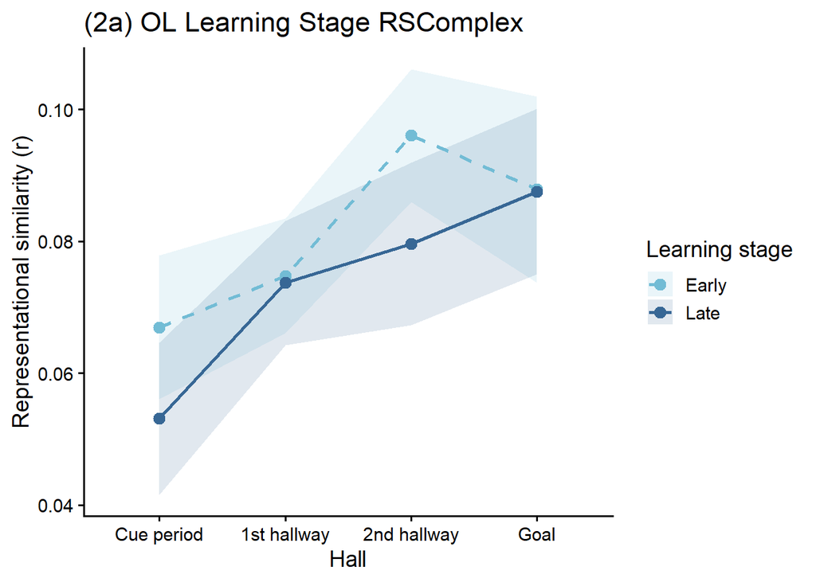

RSComplex NOL **************************

-> Repeated meausures ANOVA Learning stage (Early,Late) x Hall (Cue period, 1st hall, 2nd hall, goal) (1) NOL RSComplex

```
## # A tibble: 160 × 7
## # Groups:   ID, learningStage, Hall [160]
##    ID    raw_name                    RSA ROI   learningStage Hall  Overlappicity
##    <chr> <chr>                     <dbl> <chr> <chr>         <fct> <chr>
##  1 s01   'nol_new_early_w_nol_…  0.0629  Comp… Early         Goal  NOL
##  2 s01   'nol_new_late_w_nol_n…  0.0505  Comp… Late          Goal  NOL
##  3 s01   'nol_new_early_w_nol_…  0.0405  Comp… Early         2nd … NOL
##  4 s01   'nol_new_late_w_nol_n…  0.0886  Comp… Late          2nd … NOL
##  5 s01   'nol_new_early_w_nol_…  0.0383  Comp… Early         1st … NOL
##  6 s01   'nol_new_late_w_nol_n…  0.0908  Comp… Late          1st … NOL
##  7 s01   'nol_new_early_w_nol_…  0.116   Comp… Early         Cue … NOL
##  8 s01   'nol_new_late_w_nol_n…  0.0624  Comp… Late          Cue … NOL
##  9 s02   'nol_new_early_w_nol_… -0.00126 Comp… Early         Goal  NOL
## 10 s02   'nol_new_late_w_nol_n…  0.0849  Comp… Late          Goal  NOL
## # ℹ 150 more rows
```

ANOVA

```
## Anova Table (Type 3 tests)
##
## Response: RSA
##                    num Df den Df       MSE      F      pes Pr(>F)
## learningStage      1.0000 19.000 0.0026912 0.2140 0.011139 0.6489
## Hall               2.0451 38.857 0.0018354 2.0875 0.098993 0.1367
## learningStage:Hall 1.9064 36.222 0.0018839 3.0318 0.137610 0.0629 .
## ---
## Signif. codes:  0 '***' 0.001 '**' 0.01 '*' 0.05 '.' 0.1 ' ' 1
```

```
##               Effect                df1      df2     F       p   η.p
## 1      learningStage      learningStage 1.000000 0.214 = 0.649 0.011
## 2               Hall               Hall 2.045097 2.088 = 0.137 0.099
## 3 learningStage:Hall learningStage:Hall 1.906409 3.032 = 0.063 0.138
```

POST-HOCs

|  | contrast | estimate | SE | df | t.ratio | p.value | cohen_d | t | pHolms |
| --- | --- | --- | --- | --- | --- | --- | --- | --- | --- |
| 1 | Early Cue.period - Late Cue.period | 0.000 | 0.012 | 19 | -0.01857239 | 1.000000000 | 0.000 | -0.02 | = 1 |
| 2 | Early Cue.period - Early X1st.hallway | 0.001 | 0.013 | 19 | 0.03857767 | 1.000000000 | 0.054 | 0.04 | = 1 |
| 3 | Early Cue.period - Late X1st.hallway | -0.007 | 0.014 | 19 | -0.46145237 | 1.000000000 | -0.354 | -0.46 | = 1 |
| 4 | Early Cue.period - Early X2nd.hallway | -0.027 | 0.013 | 19 | -2.11225724 | 1.000000000 | -1.469 | -2.11 | = 1 |
| 5 | Early Cue.period - Late X2nd.hallway | -0.008 | 0.012 | 19 | -0.64852226 | 1.000000000 | -0.471 | -0.65 | = 1 |
| 6 | Early Cue.period - Early Goal | 0.001 | 0.009 | 19 | 0.16108465 | 1.000000000 | 0.079 | 0.16 | = 1 |
| 7 | Early Cue.period - Late Goal | -0.026 | 0.016 | 19 | -1.59352409 | 1.000000000 | -1.149 | -1.59 | = 1 |
| 8 | Late Cue.period - Early X1st.hallway | 0.001 | 0.011 | 19 | 0.06799186 | 1.000000000 | 0.064 | 0.07 | = 1 |
| 9 | Late Cue.period - Late X1st.hallway | -0.006 | 0.012 | 19 | -0.52780469 | 1.000000000 | -0.354 | -0.53 | = 1 |
| 10 | Late Cue.period - Early X2nd.hallway | -0.027 | 0.012 | 19 | -2.17997606 | 1.000000000 | -1.591 | -2.18 | = 1 |

[output cut: 18 more lines]

|  | contrast | estimate | SE | df | t.ratio | p.value | cohen_d | t | pBonf |
| --- | --- | --- | --- | --- | --- | --- | --- | --- | --- |
| 1 | Early Cue.period - Late Cue.period | 0.000 | 0.012 | 19 | -0.01857239 | 1.000000000 | 0.000 | -0.02 | = 1 |
| 2 | Early Cue.period - Early X1st.hallway | 0.001 | 0.013 | 19 | 0.03857767 | 1.000000000 | 0.054 | 0.04 | = 1 |
| 3 | Early Cue.period - Late X1st.hallway | -0.007 | 0.014 | 19 | -0.46145237 | 1.000000000 | -0.354 | -0.46 | = 1 |
| 4 | Early Cue.period - Early X2nd.hallway | -0.027 | 0.013 | 19 | -2.11225724 | 1.000000000 | -1.469 | -2.11 | = 1 |
| 5 | Early Cue.period - Late X2nd.hallway | -0.008 | 0.012 | 19 | -0.64852226 | 1.000000000 | -0.471 | -0.65 | = 1 |
| 6 | Early Cue.period - Early Goal | 0.001 | 0.009 | 19 | 0.16108465 | 1.000000000 | 0.079 | 0.16 | = 1 |
| 7 | Early Cue.period - Late Goal | -0.026 | 0.016 | 19 | -1.59352409 | 1.000000000 | -1.149 | -1.59 | = 1 |
| 8 | Late Cue.period - Early X1st.hallway | 0.001 | 0.011 | 19 | 0.06799186 | 1.000000000 | 0.064 | 0.07 | = 1 |
| 9 | Late Cue.period - Late X1st.hallway | -0.006 | 0.012 | 19 | -0.52780469 | 1.000000000 | -0.354 | -0.53 | = 1 |
| 10 | Late Cue.period - Early X2nd.hallway | -0.027 | 0.012 | 19 | -2.17997606 | 1.000000000 | -1.591 | -2.18 | = 1 |

[output cut: 18 more lines]

DESCRIPTIVES

```
## # A tibble: 8 × 6
##   learningStage Hall            N  Mean    SD    SE
##   <chr>         <fct>       <int> <dbl> <dbl> <dbl>
## 1 Early         Cue period     20 0.061 0.052 0.012
## 2 Early         1st hallway    20 0.061 0.039 0.009
## 3 Early         2nd hallway    20 0.088 0.053 0.012
## 4 Early         Goal           20 0.06  0.057 0.013
## 5 Late          Cue period     20 0.061 0.044 0.01
## 6 Late          1st hallway    20 0.068 0.032 0.007
## 7 Late          2nd hallway    20 0.069 0.033 0.007
## 8 Late          Goal           20 0.087 0.051 0.011
```

PLOTTING NOL RSComplex (LearningStage x Hall)

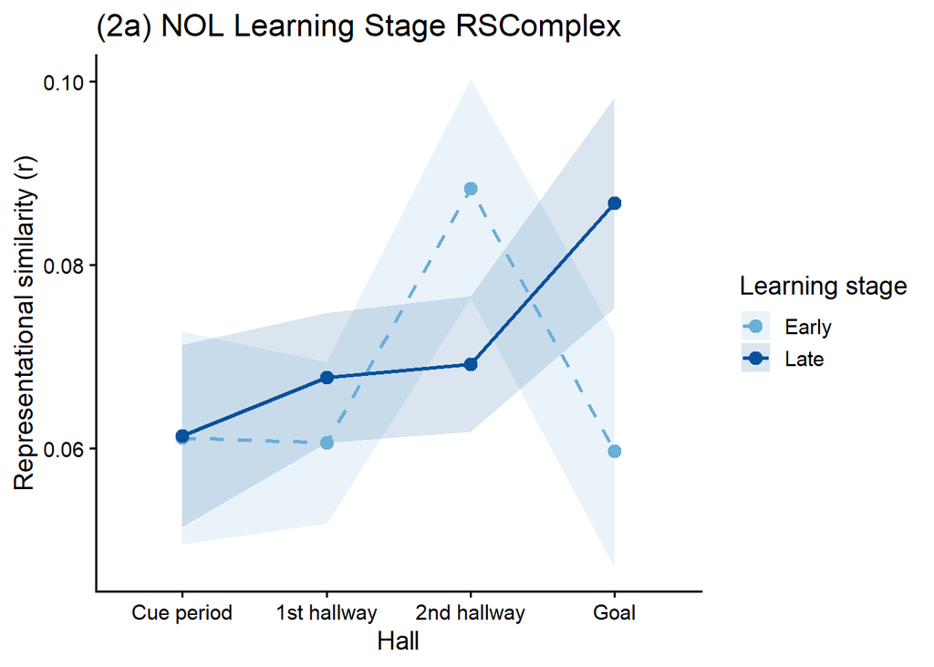

2. NATURE OF REPRESENTATIONS ************************** HC vs RSC **************************

(2a) OL EARLY HC vs RSC

```
## # A tibble: 160 × 7
## # Groups:   ID, ROI, Hall [160]
##    ID    raw_name                    RSA ROI   learningStage Hall  Overlappicity
##    <chr> <chr>                     <dbl> <chr> <chr>         <fct> <chr>
##  1 s01   'ol_new_early_w_ol_new… 0.0933  RSC   Early         Goal  OL
##  2 s01   'ol_new_early_w_ol_new… 0.0458  RSC   Early         2nd … OL
##  3 s01   'ol_new_early_w_ol_new… 0.0411  RSC   Early         1st … OL
##  4 s01   'ol_new_early_w_ol_new… 0.0639  RSC   Early         Cue … OL
##  5 s01   'ol_new_early_w_ol_new… 0.0281  Hipp… Early         Goal  OL
##  6 s01   'ol_new_early_w_ol_new… 0.0173  Hipp… Early         2nd … OL
##  7 s01   'ol_new_early_w_ol_new… 0.00717 Hipp… Early         1st … OL
##  8 s01   'ol_new_early_w_ol_new… 0.0240  Hipp… Early         Cue … OL
##  9 s02   'ol_new_early_w_ol_new… 0.0440  RSC   Early         Goal  OL
## 10 s02   'ol_new_early_w_ol_new… 0.0524  RSC   Early         2nd … OL
## # ℹ 150 more rows
```

ANOVA

```
## Anova Table (Type 3 tests)
##
## Response: RSA
##          num Df den Df        MSE       F     pes    Pr(>F)
## ROI      1.0000 19.000 0.00083844 91.2290 0.82763 1.097e-08 ***
## Hall     1.8288 34.747 0.00138705  6.7905 0.26329  0.004053 **
## ROI:Hall 2.1816 41.450 0.00038851  2.1045 0.09972  0.130801
## ---
## Signif. codes:  0 '***' 0.001 '**' 0.01 '*' 0.05 '.' 0.1 ' ' 1
```

```
##     Effect      df1      df2      F       p   η.p
## 1      ROI      ROI 1.000000 91.229  < .001 0.828
## 2     Hall     Hall 1.828788  6.790 = 0.004 0.263
## 3 ROI:Hall ROI:Hall 2.181560  2.104 = 0.131 0.100
```

POST-HOCs

[output not shown]

[output cut: 18 more lines]

[output not shown]

[output cut: 18 more lines]

[output not shown]

[output cut: 18 more lines]

DESCRIPTIVES

```
## # A tibble: 8 × 6
##   ROI         Hall            N  Mean    SD    SE
##   <chr>       <fct>       <int> <dbl> <dbl> <dbl>
## 1 Hippocampus Cue period     20 0.017 0.023 0.005
## 2 Hippocampus 1st hallway    20 0.014 0.013 0.003
## 3 Hippocampus 2nd hallway    20 0.018 0.014 0.003
## 4 Hippocampus Goal           20 0.033 0.027 0.006
## 5 RSC         Cue period     20 0.058 0.035 0.008
## 6 RSC         1st hallway    20 0.048 0.028 0.006
## 7 RSC         2nd hallway    20 0.067 0.042 0.009
## 8 RSC         Goal           20 0.084 0.044 0.01
```

PLOTTING OL EARLY HC vs RSC

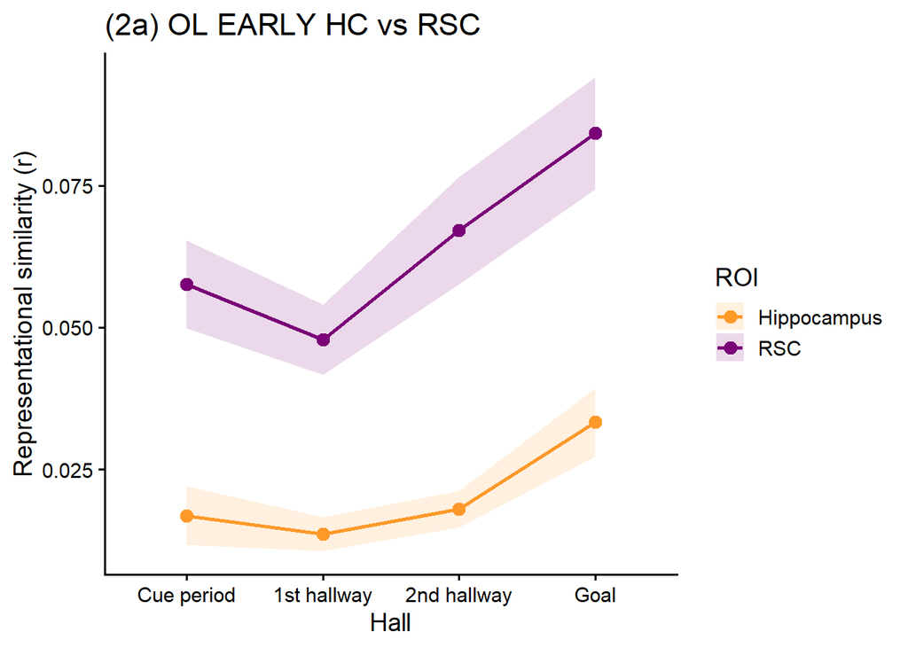

2a) OL Late HC vs RSC

```
## # A tibble: 160 × 7
## # Groups:   ID, ROI, Hall [160]
##    ID    raw_name                    RSA ROI   learningStage Hall  Overlappicity
##    <chr> <chr>                     <dbl> <chr> <chr>         <fct> <chr>
##  1 s01   'ol_new_late_w_ol_new_… 0.0572  RSC   Late          Goal  OL
##  2 s01   'ol_new_late_w_ol_new_… 0.0487  RSC   Late          2nd … OL
##  3 s01   'ol_new_late_w_ol_new_… 0.0351  RSC   Late          1st … OL
##  4 s01   'ol_new_late_w_ol_new_… 0.0648  RSC   Late          Cue … OL
##  5 s01   'ol_new_late_w_ol_new_… 0.0263  Hipp… Late          Goal  OL
##  6 s01   'ol_new_late_w_ol_new_… 0.0246  Hipp… Late          2nd … OL
##  7 s01   'ol_new_late_w_ol_new_… 0.00419 Hipp… Late          1st … OL
##  8 s01   'ol_new_late_w_ol_new_… 0.0462  Hipp… Late          Cue … OL
##  9 s02   'ol_new_late_w_ol_new_… 0.154   RSC   Late          Goal  OL
## 10 s02   'ol_new_late_w_ol_new_… 0.0768  RSC   Late          2nd … OL
## # ℹ 150 more rows
```

ANOVA

```
##     Effect      df1      df2      F       p   η.p
## 1      ROI      ROI 1.000000 73.926  < .001 0.796
## 2     Hall     Hall 2.289335  3.696 = 0.028 0.163
## 3 ROI:Hall ROI:Hall 1.862440  1.812 = 0.180 0.087
```

DESCRIPTIVES

```
## # A tibble: 8 × 6
##   ROI         Hall            N  Mean    SD    SE
##   <chr>       <fct>       <int> <dbl> <dbl> <dbl>
## 1 Hippocampus Cue period     20 0.012 0.021 0.005
## 2 Hippocampus 1st hallway    20 0.012 0.013 0.003
## 3 Hippocampus 2nd hallway    20 0.017 0.015 0.003
## 4 Hippocampus Goal           20 0.021 0.026 0.006
## 5 RSC         Cue period     20 0.047 0.039 0.009
## 6 RSC         1st hallway    20 0.049 0.031 0.007
## 7 RSC         2nd hallway    20 0.058 0.048 0.011
## 8 RSC         Goal           20 0.078 0.053 0.012
```

PLOTTING OL Late HC vs RSC

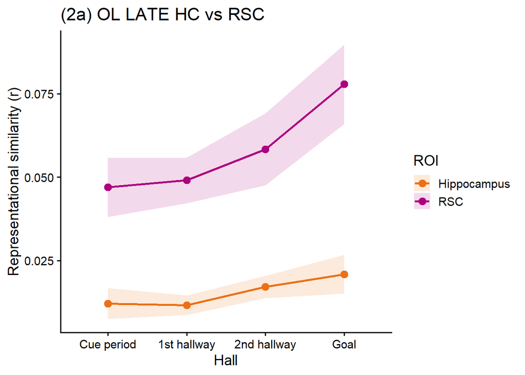

2a) NOL Early HCvsRSC

```
## # A tibble: 160 × 7
## # Groups:   ID, ROI, Hall [160]
##    ID    raw_name                    RSA ROI   learningStage Hall  Overlappicity
##    <chr> <chr>                     <dbl> <chr> <chr>         <fct> <chr>
##  1 s01   'nol_new_early_w_nol_…  0.0785  RSC   Early         Goal  NOL
##  2 s01   'nol_new_early_w_nol_…  0.0595  RSC   Early         2nd … NOL
##  3 s01   'nol_new_early_w_nol_…  0.0576  RSC   Early         1st … NOL
##  4 s01   'nol_new_early_w_nol_…  0.0882  RSC   Early         Cue … NOL
##  5 s01   'nol_new_early_w_nol_…  0.0253  Hipp… Early         Goal  NOL
##  6 s01   'nol_new_early_w_nol_…  0.0155  Hipp… Early         2nd … NOL
##  7 s01   'nol_new_early_w_nol_…  0.00548 Hipp… Early         1st … NOL
##  8 s01   'nol_new_early_w_nol_…  0.0351  Hipp… Early         Cue … NOL
##  9 s02   'nol_new_early_w_nol_…  0.0146  RSC   Early         Goal  NOL
## 10 s02   'nol_new_early_w_nol_… -0.00194 RSC   Early         2nd … NOL
## # ℹ 150 more rows
```

ANOVA

```
##     Effect      df1      df2      F       p   η.p
## 1      ROI      ROI 1.000000 50.195  < .001 0.725
## 2     Hall     Hall 2.215367  3.995 = 0.022 0.174
## 3 ROI:Hall ROI:Hall 2.196456  0.878 = 0.432 0.044
```

DESCRIPTIVES

```
## # A tibble: 8 × 6
##   ROI         Hall            N  Mean    SD    SE
##   <chr>       <fct>       <int> <dbl> <dbl> <dbl>
## 1 Hippocampus Cue period     20 0.022 0.02  0.004
## 2 Hippocampus 1st hallway    20 0.009 0.009 0.002
## 3 Hippocampus 2nd hallway    20 0.021 0.017 0.004
## 4 Hippocampus Goal           20 0.023 0.027 0.006
## 5 RSC         Cue period     20 0.051 0.039 0.009
## 6 RSC         1st hallway    20 0.041 0.026 0.006
## 7 RSC         2nd hallway    20 0.063 0.04  0.009
## 8 RSC         Goal           20 0.058 0.047 0.011
```

PLOTTING NOL Early HCvsRSC

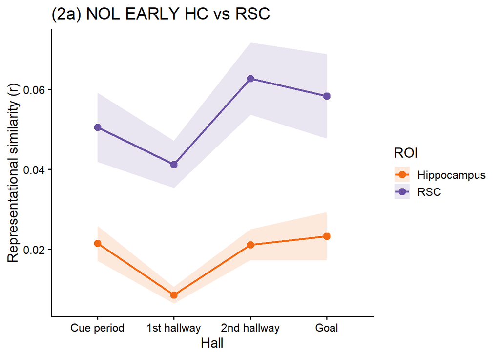

2a) NOL LATE HC vs RSC

```
## # A tibble: 160 × 7
## # Groups:   ID, ROI, Hall [160]
##    ID    raw_name                    RSA ROI   learningStage Hall  Overlappicity
##    <chr> <chr>                     <dbl> <chr> <chr>         <fct> <chr>
##  1 s01   'nol_new_late_w_nol_ne… 0.0464  RSC   Late          Goal  NOL
##  2 s01   'nol_new_late_w_nol_ne… 0.0974  RSC   Late          2nd … NOL
##  3 s01   'nol_new_late_w_nol_ne… 0.0813  RSC   Late          1st … NOL
##  4 s01   'nol_new_late_w_nol_ne… 0.0691  RSC   Late          Cue … NOL
##  5 s01   'nol_new_late_w_nol_ne… 0.00652 Hipp… Late          Goal  NOL
##  6 s01   'nol_new_late_w_nol_ne… 0.0219  Hipp… Late          2nd … NOL
##  7 s01   'nol_new_late_w_nol_ne… 0.0188  Hipp… Late          1st … NOL
##  8 s01   'nol_new_late_w_nol_ne… 0.0137  Hipp… Late          Cue … NOL
##  9 s02   'nol_new_late_w_nol_ne… 0.0702  RSC   Late          Goal  NOL
## 10 s02   'nol_new_late_w_nol_ne… 0.0913  RSC   Late          2nd … NOL
## # ℹ 150 more rows
```

ANOVA

```
##     Effect      df1      df2      F       p   η.p
## 1      ROI      ROI 1.000000 60.455  < .001 0.761
## 2     Hall     Hall 2.254918  0.515 = 0.623 0.026
## 3 ROI:Hall ROI:Hall 2.458350  0.550 = 0.616 0.028
```

DESCRIPTIVES

```
## # A tibble: 8 × 6
##   ROI         Hall            N  Mean    SD    SE
##   <chr>       <fct>       <int> <dbl> <dbl> <dbl>
## 1 Hippocampus Cue period     20 0.013 0.023 0.005
## 2 Hippocampus 1st hallway    20 0.013 0.015 0.003
## 3 Hippocampus 2nd hallway    20 0.015 0.014 0.003
## 4 Hippocampus Goal           20 0.015 0.022 0.005
## 5 RSC         Cue period     20 0.054 0.042 0.009
## 6 RSC         1st hallway    20 0.051 0.027 0.006
## 7 RSC         2nd hallway    20 0.058 0.033 0.007
## 8 RSC         Goal           20 0.064 0.047 0.01
```

PLOTTING NOL LATE HC vs RSC

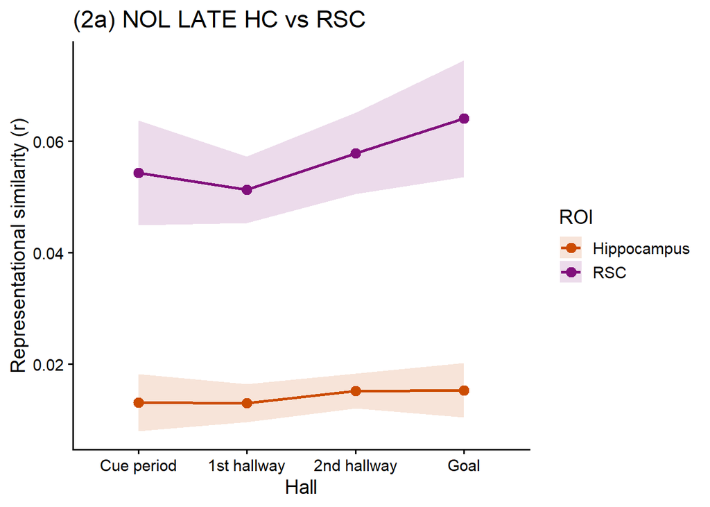

************************** HC vs RSComplex **************************

(2a) OL EARLY HC vs Complex

```
## # A tibble: 160 × 7
## # Groups:   ID, ROI, Hall [160]
##    ID    raw_name                    RSA ROI   learningStage Hall  Overlappicity
##    <chr> <chr>                     <dbl> <chr> <chr>         <fct> <chr>
##  1 s01   'ol_new_early_w_ol_new… 0.0601  Comp… Early         Goal  OL
##  2 s01   'ol_new_early_w_ol_new… 0.0361  Comp… Early         2nd … OL
##  3 s01   'ol_new_early_w_ol_new… 0.0534  Comp… Early         1st … OL
##  4 s01   'ol_new_early_w_ol_new… 0.0465  Comp… Early         Cue … OL
##  5 s01   'ol_new_early_w_ol_new… 0.0281  Hipp… Early         Goal  OL
##  6 s01   'ol_new_early_w_ol_new… 0.0173  Hipp… Early         2nd … OL
##  7 s01   'ol_new_early_w_ol_new… 0.00717 Hipp… Early         1st … OL
##  8 s01   'ol_new_early_w_ol_new… 0.0240  Hipp… Early         Cue … OL
##  9 s02   'ol_new_early_w_ol_new… 0.0285  Comp… Early         Goal  OL
## 10 s02   'ol_new_early_w_ol_new… 0.0794  Comp… Early         2nd … OL
## # ℹ 150 more rows
```

ANOVA

```
##     Effect      df1      df2      F       p   η.p
## 1      ROI      ROI 1.000000 98.481  < .001 0.838
## 2     Hall     Hall 1.905348  2.665 = 0.086 0.123
## 3 ROI:Hall ROI:Hall 2.038818  2.769 = 0.074 0.127
```

DESCRIPTIVES

```
## # A tibble: 8 × 6
##   ROI         Hall            N  Mean    SD    SE
##   <chr>       <fct>       <int> <dbl> <dbl> <dbl>
## 1 Complex     Cue period     20 0.067 0.049 0.011
## 2 Complex     1st hallway    20 0.075 0.039 0.009
## 3 Complex     2nd hallway    20 0.096 0.045 0.01
## 4 Complex     Goal           20 0.088 0.063 0.014
## 5 Hippocampus Cue period     20 0.017 0.023 0.005
## 6 Hippocampus 1st hallway    20 0.014 0.013 0.003
## 7 Hippocampus 2nd hallway    20 0.018 0.014 0.003
## 8 Hippocampus Goal           20 0.033 0.027 0.006
```

PLOTTING OL EARLY HC vs RSComplex

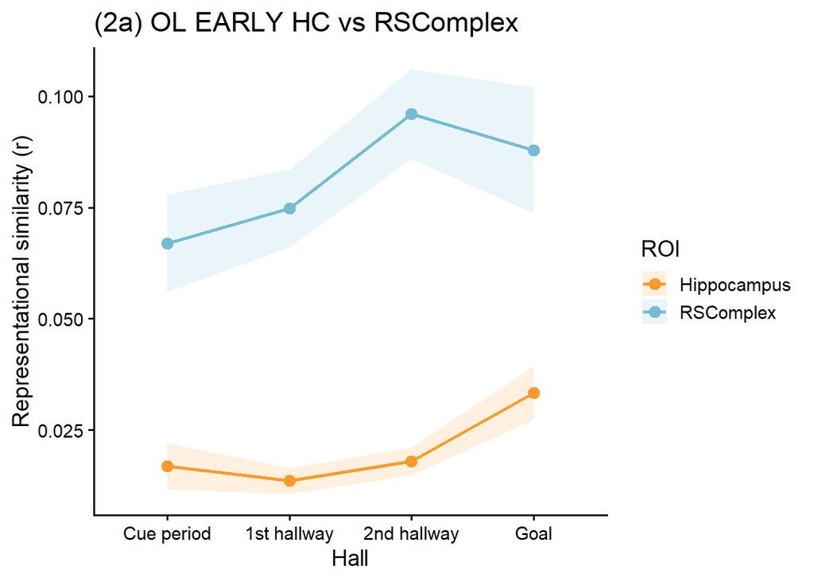

2a) OL Late HC vs Complex

```
## # A tibble: 160 × 7
## # Groups:   ID, ROI, Hall [160]
##    ID    raw_name                    RSA ROI   learningStage Hall  Overlappicity
##    <chr> <chr>                     <dbl> <chr> <chr>         <fct> <chr>
##  1 s01   'ol_new_late_w_ol_new_… 0.0541  Comp… Late          Goal  OL
##  2 s01   'ol_new_late_w_ol_new_… 0.0447  Comp… Late          2nd … OL
##  3 s01   'ol_new_late_w_ol_new_… 0.0587  Comp… Late          1st … OL
##  4 s01   'ol_new_late_w_ol_new_… 0.0693  Comp… Late          Cue … OL
##  5 s01   'ol_new_late_w_ol_new_… 0.0263  Hipp… Late          Goal  OL
##  6 s01   'ol_new_late_w_ol_new_… 0.0246  Hipp… Late          2nd … OL
##  7 s01   'ol_new_late_w_ol_new_… 0.00419 Hipp… Late          1st … OL
##  8 s01   'ol_new_late_w_ol_new_… 0.0462  Hipp… Late          Cue … OL
##  9 s02   'ol_new_late_w_ol_new_… 0.138   Comp… Late          Goal  OL
## 10 s02   'ol_new_late_w_ol_new_… 0.128   Comp… Late          2nd … OL
## # ℹ 150 more rows
```

ANOVA

```
##     Effect      df1      df2       F       p   η.p
## 1      ROI      ROI 1.000000 113.743  < .001 0.857
## 2     Hall     Hall 1.884540   2.553 = 0.095 0.118
## 3 ROI:Hall ROI:Hall 1.834352   1.544 = 0.228 0.075
```

DESCRIPTIVES

```
## # A tibble: 8 × 6
##   ROI         Hall            N  Mean    SD    SE
##   <chr>       <fct>       <int> <dbl> <dbl> <dbl>
## 1 Complex     Cue period     20 0.053 0.052 0.012
## 2 Complex     1st hallway    20 0.074 0.042 0.009
## 3 Complex     2nd hallway    20 0.08  0.055 0.012
## 4 Complex     Goal           20 0.088 0.056 0.013
## 5 Hippocampus Cue period     20 0.012 0.021 0.005
## 6 Hippocampus 1st hallway    20 0.012 0.013 0.003
## 7 Hippocampus 2nd hallway    20 0.017 0.015 0.003
## 8 Hippocampus Goal           20 0.021 0.026 0.006
```

PLOTTING OL Late HC vs RSComplex

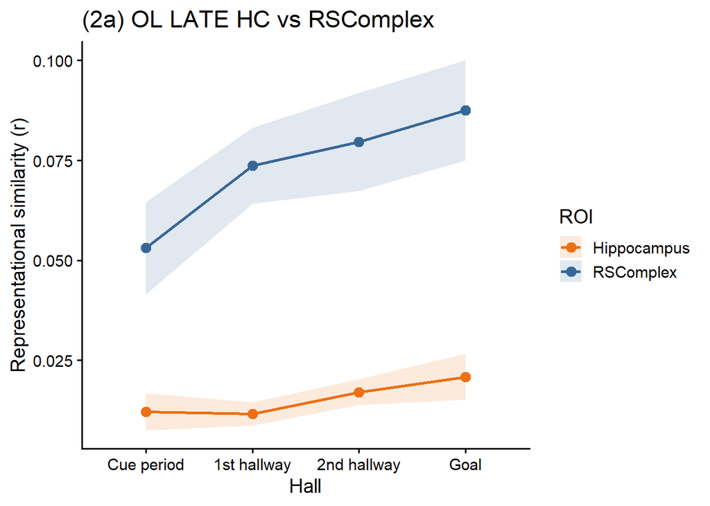

2a) NOL Early HC vs Complex

```
## # A tibble: 160 × 7
## # Groups:   ID, ROI, Hall [160]
##    ID    raw_name                    RSA ROI   learningStage Hall  Overlappicity
##    <chr> <chr>                     <dbl> <chr> <chr>         <fct> <chr>
##  1 s01   'nol_new_early_w_nol_…  0.0629  Comp… Early         Goal  NOL
##  2 s01   'nol_new_early_w_nol_…  0.0405  Comp… Early         2nd … NOL
##  3 s01   'nol_new_early_w_nol_…  0.0383  Comp… Early         1st … NOL
##  4 s01   'nol_new_early_w_nol_…  0.116   Comp… Early         Cue … NOL
##  5 s01   'nol_new_early_w_nol_…  0.0253  Hipp… Early         Goal  NOL
##  6 s01   'nol_new_early_w_nol_…  0.0155  Hipp… Early         2nd … NOL
##  7 s01   'nol_new_early_w_nol_…  0.00548 Hipp… Early         1st … NOL
##  8 s01   'nol_new_early_w_nol_…  0.0351  Hipp… Early         Cue … NOL
##  9 s02   'nol_new_early_w_nol_… -0.00126 Comp… Early         Goal  NOL
## 10 s02   'nol_new_early_w_nol_…  0.0138  Comp… Early         2nd … NOL
## # ℹ 150 more rows
```

ANOVA

```
##     Effect      df1      df2      F       p   η.p
## 1      ROI      ROI 1.000000 50.550  < .001 0.727
## 2     Hall     Hall 1.766995  2.933 = 0.073 0.134
## 3 ROI:Hall ROI:Hall 2.063824  3.872 = 0.028 0.169
```

DESCRIPTIVES

```
## # A tibble: 8 × 6
##   ROI         Hall            N  Mean    SD    SE
##   <chr>       <fct>       <int> <dbl> <dbl> <dbl>
## 1 Complex     Cue period     20 0.061 0.052 0.012
## 2 Complex     1st hallway    20 0.061 0.039 0.009
## 3 Complex     2nd hallway    20 0.088 0.053 0.012
## 4 Complex     Goal           20 0.06  0.057 0.013
## 5 Hippocampus Cue period     20 0.022 0.02  0.004
## 6 Hippocampus 1st hallway    20 0.009 0.009 0.002
## 7 Hippocampus 2nd hallway    20 0.021 0.017 0.004
## 8 Hippocampus Goal           20 0.023 0.027 0.006
```

PLOTTING NOL Early HC vs RSComplex

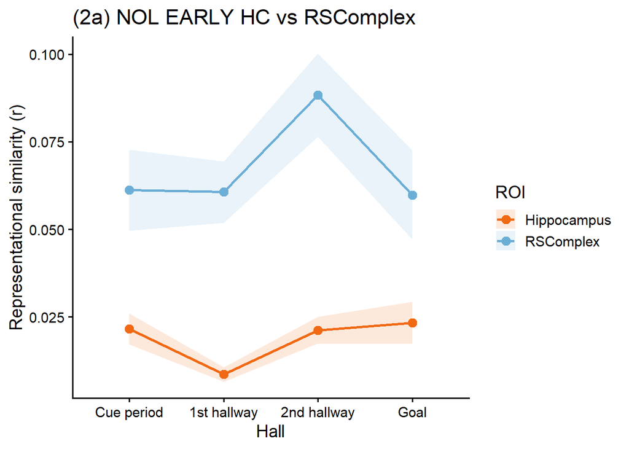

2a) NOL LATE HC vs Complex

```
## # A tibble: 160 × 7
## # Groups:   ID, ROI, Hall [160]
##    ID    raw_name                    RSA ROI   learningStage Hall  Overlappicity
##    <chr> <chr>                     <dbl> <chr> <chr>         <fct> <chr>
##  1 s01   'nol_new_late_w_nol_ne… 0.0505  Comp… Late          Goal  NOL
##  2 s01   'nol_new_late_w_nol_ne… 0.0886  Comp… Late          2nd … NOL
##  3 s01   'nol_new_late_w_nol_ne… 0.0908  Comp… Late          1st … NOL
##  4 s01   'nol_new_late_w_nol_ne… 0.0624  Comp… Late          Cue … NOL
##  5 s01   'nol_new_late_w_nol_ne… 0.00652 Hipp… Late          Goal  NOL
##  6 s01   'nol_new_late_w_nol_ne… 0.0219  Hipp… Late          2nd … NOL
##  7 s01   'nol_new_late_w_nol_ne… 0.0188  Hipp… Late          1st … NOL
##  8 s01   'nol_new_late_w_nol_ne… 0.0137  Hipp… Late          Cue … NOL
##  9 s02   'nol_new_late_w_nol_ne… 0.0849  Comp… Late          Goal  NOL
## 10 s02   'nol_new_late_w_nol_ne… 0.105   Comp… Late          2nd … NOL
## # ℹ 150 more rows
```

ANOVA

```
##     Effect      df1      df2      F       p   η.p
## 1      ROI      ROI 1.000000 97.824  < .001 0.837
## 2     Hall     Hall 2.122555  1.431 = 0.251 0.070
## 3 ROI:Hall ROI:Hall 2.340200  2.326 = 0.101 0.109
```

DESCRIPTIVES

```
## # A tibble: 8 × 6
##   ROI         Hall            N  Mean    SD    SE
##   <chr>       <fct>       <int> <dbl> <dbl> <dbl>
## 1 Complex     Cue period     20 0.061 0.044 0.01
## 2 Complex     1st hallway    20 0.068 0.032 0.007
## 3 Complex     2nd hallway    20 0.069 0.033 0.007
## 4 Complex     Goal           20 0.087 0.051 0.011
## 5 Hippocampus Cue period     20 0.013 0.023 0.005
## 6 Hippocampus 1st hallway    20 0.013 0.015 0.003
## 7 Hippocampus 2nd hallway    20 0.015 0.014 0.003
## 8 Hippocampus Goal           20 0.015 0.022 0.005
```

PLOTTING NOL LATE HC vs Complex

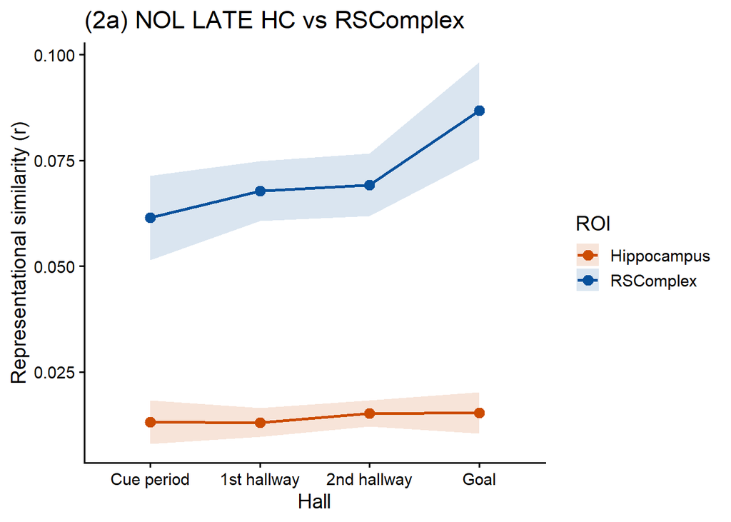

************************************** RSC vs RSComplex ************************************** (2a) OL EARLY RSC vs Complex

```
## # A tibble: 160 × 7
## # Groups:   ID, ROI, Hall [160]
##    ID    raw_name                    RSA ROI   learningStage Hall  Overlappicity
##    <chr> <chr>                     <dbl> <chr> <chr>         <fct> <chr>
##  1 s01   'ol_new_early_w_ol_new_… 0.0601 Comp… Early         Goal  OL
##  2 s01   'ol_new_early_w_ol_new_… 0.0361 Comp… Early         2nd … OL
##  3 s01   'ol_new_early_w_ol_new_… 0.0534 Comp… Early         1st … OL
##  4 s01   'ol_new_early_w_ol_new_… 0.0465 Comp… Early         Cue … OL
##  5 s01   'ol_new_early_w_ol_new_… 0.0933 RSC   Early         Goal  OL
##  6 s01   'ol_new_early_w_ol_new_… 0.0458 RSC   Early         2nd … OL
##  7 s01   'ol_new_early_w_ol_new_… 0.0411 RSC   Early         1st … OL
##  8 s01   'ol_new_early_w_ol_new_… 0.0639 RSC   Early         Cue … OL
##  9 s02   'ol_new_early_w_ol_new_… 0.0285 Comp… Early         Goal  OL
## 10 s02   'ol_new_early_w_ol_new_… 0.0794 Comp… Early         2nd … OL
## # ℹ 150 more rows
```

ANOVA

```
##     Effect      df1      df2      F       p   η.p
## 1      ROI      ROI 1.000000 20.809  < .001 0.523
## 2     Hall     Hall 1.859263  3.030 = 0.064 0.138
## 3 ROI:Hall ROI:Hall 2.372395  6.007 = 0.003 0.240
```

DESCRIPTIVES

```
## # A tibble: 8 × 6
##   ROI     Hall            N  Mean    SD    SE
##   <chr>   <fct>       <int> <dbl> <dbl> <dbl>
## 1 Complex Cue period     20 0.067 0.049 0.011
## 2 Complex 1st hallway    20 0.075 0.039 0.009
## 3 Complex 2nd hallway    20 0.096 0.045 0.01
## 4 Complex Goal           20 0.088 0.063 0.014
## 5 RSC     Cue period     20 0.058 0.035 0.008
## 6 RSC     1st hallway    20 0.048 0.028 0.006
## 7 RSC     2nd hallway    20 0.067 0.042 0.009
## 8 RSC     Goal           20 0.084 0.044 0.01
```

PLOTTING OL EARLY RSC vs Complex

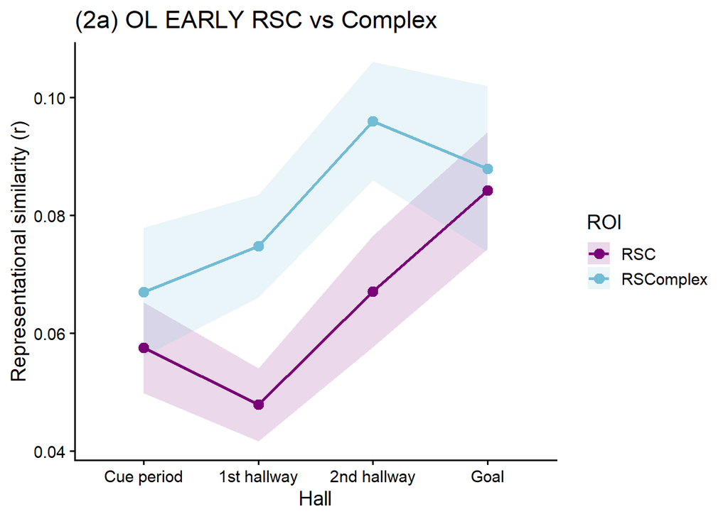

2a) OL Late RSC vs Complex

```
## # A tibble: 160 × 7
## # Groups:   ID, ROI, Hall [160]
##    ID    raw_name                    RSA ROI   learningStage Hall  Overlappicity
##    <chr> <chr>                     <dbl> <chr> <chr>         <fct> <chr>
##  1 s01   'ol_new_late_w_ol_new_l… 0.0541 Comp… Late          Goal  OL
##  2 s01   'ol_new_late_w_ol_new_l… 0.0447 Comp… Late          2nd … OL
##  3 s01   'ol_new_late_w_ol_new_l… 0.0587 Comp… Late          1st … OL
##  4 s01   'ol_new_late_w_ol_new_l… 0.0693 Comp… Late          Cue … OL
##  5 s01   'ol_new_late_w_ol_new_l… 0.0572 RSC   Late          Goal  OL
##  6 s01   'ol_new_late_w_ol_new_l… 0.0487 RSC   Late          2nd … OL
##  7 s01   'ol_new_late_w_ol_new_l… 0.0351 RSC   Late          1st … OL
##  8 s01   'ol_new_late_w_ol_new_l… 0.0648 RSC   Late          Cue … OL
##  9 s02   'ol_new_late_w_ol_new_l… 0.138  Comp… Late          Goal  OL
## 10 s02   'ol_new_late_w_ol_new_l… 0.128  Comp… Late          2nd … OL
## # ℹ 150 more rows
```

ANOVA

```
##     Effect      df1      df2      F       p   η.p
## 1      ROI      ROI 1.000000 22.930  < .001 0.547
## 2     Hall     Hall 1.944082  2.486 = 0.098 0.116
## 3 ROI:Hall ROI:Hall 2.191415  3.343 = 0.041 0.150
```

DESCRIPTIVES

```
## # A tibble: 8 × 6
##   ROI     Hall            N  Mean    SD    SE
##   <chr>   <fct>       <int> <dbl> <dbl> <dbl>
## 1 Complex Cue period     20 0.053 0.052 0.012
## 2 Complex 1st hallway    20 0.074 0.042 0.009
## 3 Complex 2nd hallway    20 0.08  0.055 0.012
## 4 Complex Goal           20 0.088 0.056 0.013
## 5 RSC     Cue period     20 0.047 0.039 0.009
## 6 RSC     1st hallway    20 0.049 0.031 0.007
## 7 RSC     2nd hallway    20 0.058 0.048 0.011
## 8 RSC     Goal           20 0.078 0.053 0.012
```

PLOTTING OL Late RSC vs Complex

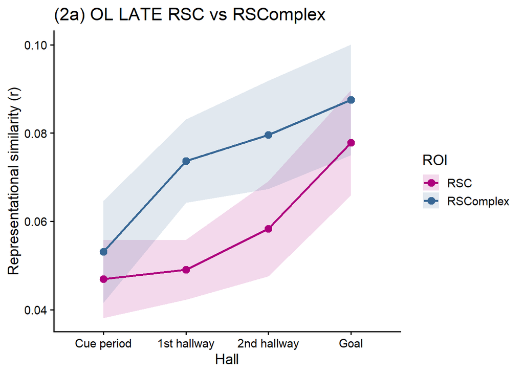

2a) NOL Early RSC vs Complex

```
## # A tibble: 160 × 7
## # Groups:   ID, ROI, Hall [160]
##    ID    raw_name                    RSA ROI   learningStage Hall  Overlappicity
##    <chr> <chr>                     <dbl> <chr> <chr>         <fct> <chr>
##  1 s01   'nol_new_early_w_nol_…  0.0629  Comp… Early         Goal  NOL
##  2 s01   'nol_new_early_w_nol_…  0.0405  Comp… Early         2nd … NOL
##  3 s01   'nol_new_early_w_nol_…  0.0383  Comp… Early         1st … NOL
##  4 s01   'nol_new_early_w_nol_…  0.116   Comp… Early         Cue … NOL
##  5 s01   'nol_new_early_w_nol_…  0.0785  RSC   Early         Goal  NOL
##  6 s01   'nol_new_early_w_nol_…  0.0595  RSC   Early         2nd … NOL
##  7 s01   'nol_new_early_w_nol_…  0.0576  RSC   Early         1st … NOL
##  8 s01   'nol_new_early_w_nol_…  0.0882  RSC   Early         Cue … NOL
##  9 s02   'nol_new_early_w_nol_… -0.00126 Comp… Early         Goal  NOL
## 10 s02   'nol_new_early_w_nol_…  0.0138  Comp… Early         2nd … NOL
## # ℹ 150 more rows
```

ANOVA

```
##     Effect      df1      df2      F       p   η.p
## 1      ROI      ROI 1.000000 12.802 = 0.002 0.403
## 2     Hall     Hall 2.133863  2.747 = 0.073 0.126
## 3 ROI:Hall ROI:Hall 1.944291  3.617 = 0.038 0.160
```

DESCRIPTIVES

```
## # A tibble: 8 × 6
##   ROI     Hall            N  Mean    SD    SE
##   <chr>   <fct>       <int> <dbl> <dbl> <dbl>
## 1 Complex Cue period     20 0.061 0.052 0.012
## 2 Complex 1st hallway    20 0.061 0.039 0.009
## 3 Complex 2nd hallway    20 0.088 0.053 0.012
## 4 Complex Goal           20 0.06  0.057 0.013
## 5 RSC     Cue period     20 0.051 0.039 0.009
## 6 RSC     1st hallway    20 0.041 0.026 0.006
## 7 RSC     2nd hallway    20 0.063 0.04  0.009
## 8 RSC     Goal           20 0.058 0.047 0.011
```

PLOTTING NOL Early RSC vs RSComplex

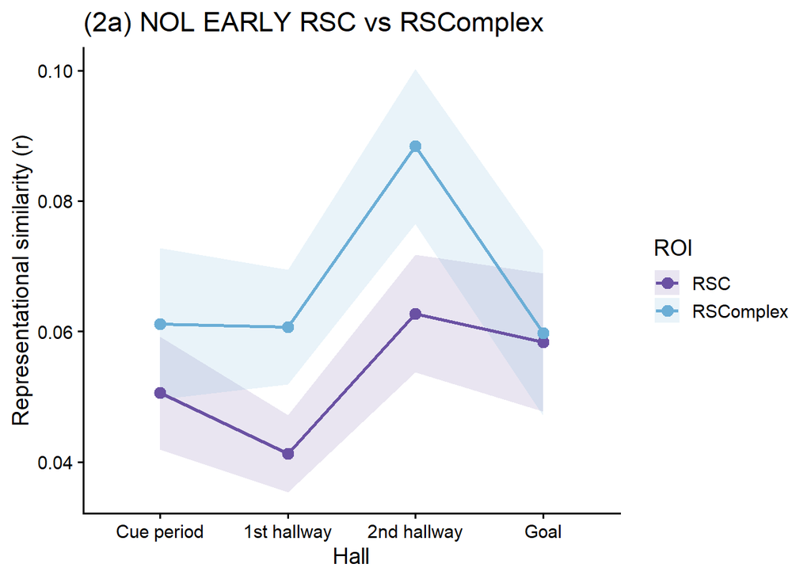

2a) NOL LATE RSC vs RSComplex

```
## # A tibble: 160 × 7
## # Groups:   ID, ROI, Hall [160]
##    ID    raw_name                    RSA ROI   learningStage Hall  Overlappicity
##    <chr> <chr>                     <dbl> <chr> <chr>         <fct> <chr>
##  1 s01   'nol_new_late_w_nol_new… 0.0505 Comp… Late          Goal  NOL
##  2 s01   'nol_new_late_w_nol_new… 0.0886 Comp… Late          2nd … NOL
##  3 s01   'nol_new_late_w_nol_new… 0.0908 Comp… Late          1st … NOL
##  4 s01   'nol_new_late_w_nol_new… 0.0624 Comp… Late          Cue … NOL
##  5 s01   'nol_new_late_w_nol_new… 0.0464 RSC   Late          Goal  NOL
##  6 s01   'nol_new_late_w_nol_new… 0.0974 RSC   Late          2nd … NOL
##  7 s01   'nol_new_late_w_nol_new… 0.0813 RSC   Late          1st … NOL
##  8 s01   'nol_new_late_w_nol_new… 0.0691 RSC   Late          Cue … NOL
##  9 s02   'nol_new_late_w_nol_new… 0.0849 Comp… Late          Goal  NOL
## 10 s02   'nol_new_late_w_nol_new… 0.105  Comp… Late          2nd … NOL
## # ℹ 150 more rows
```

ANOVA

```
##     Effect      df1      df2      F       p   η.p
## 1      ROI      ROI 1.000000 19.942  < .001 0.512
## 2     Hall     Hall 2.314918  1.219 = 0.309 0.060
## 3 ROI:Hall ROI:Hall 2.494407  3.730 = 0.023 0.164
```

DESCRIPTIVES

```
## # A tibble: 8 × 6
##   ROI     Hall            N  Mean    SD    SE
##   <chr>   <fct>       <int> <dbl> <dbl> <dbl>
## 1 Complex Cue period     20 0.061 0.044 0.01
## 2 Complex 1st hallway    20 0.068 0.032 0.007
## 3 Complex 2nd hallway    20 0.069 0.033 0.007
## 4 Complex Goal           20 0.087 0.051 0.011
## 5 RSC     Cue period     20 0.054 0.042 0.009
## 6 RSC     1st hallway    20 0.051 0.027 0.006
## 7 RSC     2nd hallway    20 0.058 0.033 0.007
## 8 RSC     Goal           20 0.064 0.047 0.01
```

PLOTTING NOL LATE RSC vs RSCComplex

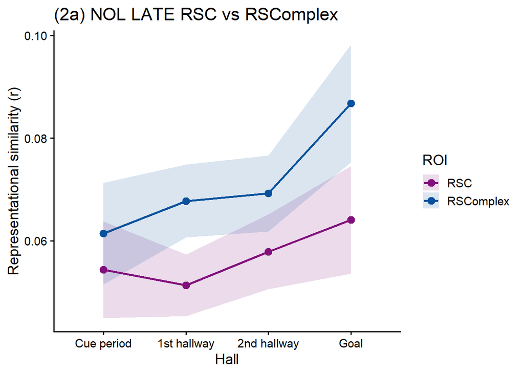